# DA 5020 Assignment 10

Jiaming Xu

## Q1. Definition of confident interval and prediction interval.

A confident interval describes how well the determination of a parameter. For example, a 95% confident interval means 95 events happened within a range of values out of 100 events statistically (population mean).

A prediction interval describes what’s the expected range of value for the next data point (individually).

Also, a prediction interval has a larger range than a confident interval, and it’s not necessary to be converged to a single value as sample size increases.

A prediction interval includes the range of individual values of the population, while a confident interval describes the range of population mean could lies in for 95% cases (if we use 95% confidence and prediction intervals).

## Q2.

```r
library(openintro)
library(tidyverse)
library(psych)
df <- sapply(ncbirths,as.numeric)
df[,c(3,5,7,10,11,12,13)] <- df[,c(3,5,7,10,11,12,13)] - 1
df <- as.data.frame(df)
cor(df, use='complete.obs')
```

```
##                        fage         mage       mature        weeks       premie
## fage            1.000000000  0.780647662 -0.496405435 -0.007996662 -0.011323219
## mage            0.780647662  1.000000000 -0.641402623 -0.040007598  0.002518252
## mature         -0.496405435 -0.641402623  1.000000000  0.064254950 -0.045384586
## weeks          -0.007996662 -0.040007598  0.064254950  1.000000000 -0.725519124
## premie         -0.011323219  0.002518252 -0.045384586 -0.725519124  1.000000000
## visits          0.085239020  0.142896825 -0.047617295  0.166716794 -0.122986075
## marital         0.349831445  0.419957454 -0.123953574  0.057601287 -0.054221645
## gained         -0.038945787 -0.059486097  0.028885257  0.098579712 -0.139806529
## weight          0.073335128  0.051698001  0.014963917  0.635889112 -0.533518416
## lowbirthweight  0.005084369  0.006466107  0.049700950  0.585673869 -0.562401263
## gender          0.060527775  0.014025174  0.001850802  0.013933733  0.034383502
## habit          -0.087923707 -0.113418263  0.073478706 -0.018179728  0.046544903
## whitemom        0.122129022  0.121612867 -0.032331303  0.079183972 -0.051757567
##                     visits      marital      gained      weight lowbirthweight
## fage            0.08523902  0.349831445 -0.03894579  0.07333513    0.005084369
## mage            0.14289682  0.419957454 -0.05948610  0.05169800    0.006466107
## mature         -0.04761729 -0.123953574  0.02888526  0.01496392    0.049700950
## weeks           0.16671679  0.057601287  0.09857971  0.63588911    0.585673869
## premie         -0.12298607 -0.054221645 -0.13980653 -0.53351842   -0.562401263
## visits          1.00000000  0.183586084  0.05589346  0.13128009    0.128901977
## marital         0.18358608  1.000000000 -0.01480034  0.14170933    0.100833454
## gained          0.05589346 -0.014800338  1.00000000  0.16605345    0.120395787
## weight          0.13128009  0.141709325  0.16605345  1.00000000    0.701704208
## lowbirthweight  0.12890198  0.100833454  0.12039579  0.70170421    1.000000000
## gender         -0.05589491  0.003420028  0.03093189  0.13789311    0.004638293
## habit          -0.03251382 -0.051816216  0.01047751 -0.07670461   -0.059531939
## whitemom        0.02475833  0.243026156  0.06208170  0.14794905    0.084029557
##                      gender       habit    whitemom
## fage            0.060527775 -0.08792371  0.12212902
## mage            0.014025174 -0.11341826  0.12161287
## mature          0.001850802  0.07347871 -0.03233130
## weeks           0.013933733 -0.01817973  0.07918397
## premie          0.034383502  0.04654490 -0.05175757
## visits         -0.055894906 -0.03251382  0.02475833
## marital         0.003420028 -0.05181622  0.24302616
## gained          0.030931892  0.01047751  0.06208170
## weight          0.137893106 -0.07670461  0.14794905
## lowbirthweight  0.004638293 -0.05953194  0.08402956
## gender          1.000000000  0.03690510 -0.04853164
## habit           0.036905097  1.00000000  0.05942992
## whitemom       -0.048531643  0.05942992  1.00000000
```

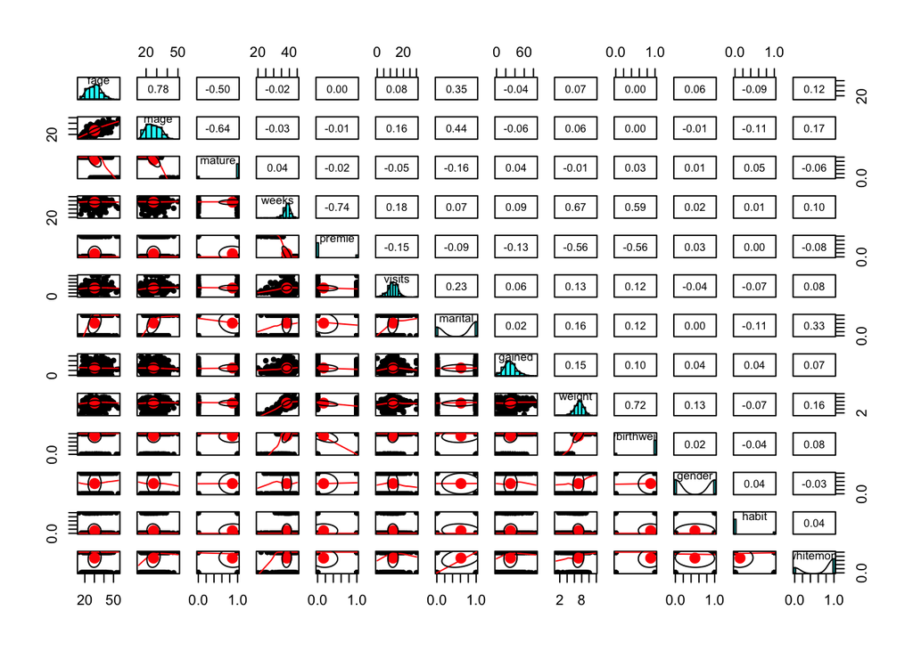

```r
pairs.panels(df)
```

## Q3: Full multiple regression model.

df here contains dummy codes for categorical variables for linear regression aims.

```r
birthw.lm <- lm(weight ~ ., data = df)

# R-squared
summary(birthw.lm)$r.squared
```

```
## [1] 0.6049462
```

```r
summary(birthw.lm)$adj.r.squared
```

```
## [1] 0.5989225
```

R squared value is 0.605, not really good. Adj. R suqred is 0.6.

```r
# standard error
summary(birthw.lm)$sigma
```

```
## [1] 0.9125829
```

Standard error is 0.913, it means our prediction would have +/- 0.913 error.

```r
# f-statistic
summary(birthw.lm)$fstatistic
```

```
##    value    numdf    dendf
## 100.4278  12.0000 787.0000
```

F statistics show 12 freedom means 12 variables used in lm. F value is 100 is a reansonable high value, the lm model is not bad.

```r
# p values
summary(birthw.lm)$coefficients[,4]
```

```
##    (Intercept)           fage           mage         mature          weeks
##   7.656618e-04   2.748124e-01   9.751060e-01   9.552122e-01   2.577690e-20
##         premie         visits        marital         gained lowbirthweight
##   7.586984e-01   9.143059e-01   1.299446e-01   2.833639e-03   5.454512e-54
##         gender          habit       whitemom
##   8.110677e-09   4.517735e-02   2.437877e-03
```

p values for 12 variables are listed above. Several of them are extremely small which means they’re statistically significant.

## Q4: Multi-regression model with p value backward elimination.

```r
lm_backelim_p <- function(x_train, keep = FALSE, loop = 10, trace = 1, p = 0.1){
  test <- x_train
  x.lm <- lm(formula = weight ~ . , data = test)
  for (q in 1:loop) {
    n = 1
    if (trace == 1) {
      print(q)
      print(sprintf("Standard Error is %.5f, AR2 is %.5f",
                    summary(x.lm)$sigma,
                    summary(x.lm)$adj.r.squared))
      print(summary(x.lm)$coefficients)
    }
    lm.summary <- summary(x.lm)$coefficients[, 4]
    p.to.drop <- names(sort(lm.summary, decreasing = TRUE))[n]
    ## Jump to second or third highest p value if highest is in keep input.
    while(any(p.to.drop == keep)){

      n = n + 1
      p.to.drop <- names(sort(lm.summary, decreasing = TRUE))[n]
    }

    if ( lm.summary[p.to.drop] > p ) {
      print(sprintf("%s is removed since it's p value is %.3f", p.to.drop, lm.summary[p.to.drop]))
      p.to.drop <- str_remove_all(p.to.drop, '`')
      test <- dplyr::select(test, -p.to.drop)

    }
    else{break} # Stop while loop if no p grater than the threshold.
    x.lm <- lm(formula = weight ~ . , data = test)
  }

  print("p backward elimination terminated since no p values satisfy the cutting criteria.")
  x.lm
}

p_lm <- lm_backelim_p(df, trace = 1, p = 0.05, loop = 20)
```

```
## [1] 1
## [1] "Standard Error is 0.91258, AR2 is 0.59892"
##                     Estimate  Std. Error     t value     Pr(>|t|)
## (Intercept)    -2.5160067778 0.744791122 -3.37813744 7.656618e-04
## fage            0.0084262030 0.007710596  1.09280823 2.748124e-01
## mage            0.0003153269 0.010101766  0.03121502 9.751060e-01
## mature         -0.0068293192 0.121560195 -0.05618055 9.552122e-01
## weeks           0.1723625366 0.018154278  9.49432065 2.577690e-20
## premie         -0.0442004934 0.143836293 -0.30729722 7.586984e-01
## visits          0.0009585140 0.008904519  0.10764355 9.143059e-01
## marital         0.1272476036 0.083941605  1.51590626 1.299446e-01
## gained          0.0070000202 0.002337503  2.99465776 2.833639e-03
## lowbirthweight  2.3906454426 0.142885240 16.73122738 5.454512e-54
## gender          0.3803504968 0.065246197  5.82946613 8.110677e-09
## habit          -0.2139059689 0.106622805 -2.00619342 4.517735e-02
## whitemom        0.2441425901 0.080289343  3.04078449 2.437877e-03
## [1] "mage is removed since it's p value is 0.975"
```

```
## Note: Using an external vector in selections is ambiguous.
## ℹ Use `all_of(p.to.drop)` instead of `p.to.drop` to silence this message.
## ℹ See <https://tidyselect.r-lib.org/reference/faq-external-vector.html>.
```

```
## [1] 2
## [1] "Standard Error is 0.91200, AR2 is 0.59943"
##                     Estimate  Std. Error    t value     Pr(>|t|)
## (Intercept)    -2.5095872065 0.715380729 -3.5080442 4.769914e-04
## fage            0.0085815344 0.005886172  1.4579143 1.452626e-01
## mature         -0.0087169705 0.105384329 -0.0827160 9.340984e-01
## weeks           0.1723200074 0.018091601  9.5248622 1.975150e-20
## premie         -0.0443527438 0.143662418 -0.3087289 7.576093e-01
## visits          0.0009855848 0.008856567  0.1112829 9.114203e-01
## marital         0.1280114636 0.080244586  1.5952661 1.110537e-01
## gained          0.0069960834 0.002332618  2.9992412 2.791726e-03
## lowbirthweight  2.3907663022 0.142742202 16.7488400 4.293345e-54
## gender          0.3803047132 0.065188347  5.8339370 7.901288e-09
## habit          -0.2140848559 0.106401171 -2.0120536 4.455417e-02
## whitemom        0.2441671129 0.080234591  3.0431652 2.418798e-03
## [1] "mature is removed since it's p value is 0.934"
## [1] 3
## [1] "Standard Error is 0.91143, AR2 is 0.59994"
##                    Estimate  Std. Error    t value     Pr(>|t|)
## (Intercept)    -2.522083591 0.698806291 -3.6091312 3.266044e-04
## fage            0.008817092 0.005148177  1.7126629 8.716746e-02
## weeks           0.172277541 0.018072930  9.5323528 1.846000e-20
## premie         -0.044226347 0.143563849 -0.3080605 7.581176e-01
## visits          0.001003514 0.008848340  0.1134127 9.097322e-01
## marital         0.127643095 0.080070471  1.5941344 1.113064e-01
## gained          0.006995922 0.002331148  3.0010626 2.775162e-03
## lowbirthweight  2.390548603 0.142628084 16.7607145 3.627922e-54
## gender          0.380114164 0.065106615  5.8383340 7.700436e-09
## habit          -0.214397842 0.106266923 -2.0175407 4.397723e-02
## whitemom        0.244077403 0.080176751  3.0442416 2.410161e-03
## [1] "visits is removed since it's p value is 0.910"
## [1] 4
## [1] "Standard Error is 0.90934, AR2 is 0.61443"
##                    Estimate  Std. Error    t value     Pr(>|t|)
## (Intercept)    -2.692472756 0.677344087 -3.9750443 7.675498e-05
## fage            0.009452241 0.005105209  1.8514896 6.446886e-02
## weeks           0.176366755 0.017435962 10.1151146 1.037752e-22
## premie         -0.031065922 0.142479089 -0.2180385 8.274550e-01
## marital         0.120297956 0.078244589  1.5374604 1.245775e-01
## gained          0.007239856 0.002302353  3.1445466 1.725137e-03
```

[output cut: 15 more lines]

```
## habit          -0.214158891 0.105861697 -2.023006 4.340546e-02
## whitemom        0.242532377 0.079214360  3.061722 2.274492e-03
## [1] "marital is removed since it's p value is 0.125"
## [1] 6
## [1] "Standard Error is 0.90957, AR2 is 0.61424"
##                    Estimate  Std. Error   t value     Pr(>|t|)
## (Intercept)    -2.812097236 0.504712563 -5.571681 3.449326e-08
## fage            0.012052734 0.004823047  2.498988 1.265457e-02
## weeks           0.178587709 0.014091689 12.673265 1.138455e-33
## gained          0.007176055 0.002292573  3.130132 1.810820e-03
## lowbirthweight  2.420213892 0.137701592 17.575787 1.034286e-58
## gender          0.373681806 0.064397617  5.802727 9.403077e-09
## habit          -0.219059967 0.105903768 -2.068481 3.891598e-02
## whitemom        0.268786895 0.077415974  3.471982 5.443793e-04
## [1] "p backward elimination terminated since no p values satisfy the cutting criteria."
```

I write a p value backward elimination function called lm_backelim_p. It drop variables based on it’s p value if it’s larger than the setting value. Here, the value for dropping is p > 0.05. Standard error and adjusted R suqared are printed after each step, and the variable dropped by each step is also printed out with its p value.

In total, mage, mature, visits, premie, marital are dropped since their p values are larger than 0.05. Standard error decreases as p elimination goes on, but fluctuated at the end. Same trends for adjusted R squared.

## Q5: Prediction

```r
test_sample <- data.frame("fage"=40, "mage"=32, "mature"="mature mom", "weeks"=42, "premie"="full term", "visits"=12, "marital"="married", "gained"=22, "weight"=NA, "lowbirthweight"="not low", "gender" = "female", "habit" = "nonsmoker", "whitemom"="white")

# Convert categorical variables to numeric. Row concatenate test sample to the end of training dataset, then convert. The predict function is used for prediction.
test_df <- sapply(as_tibble(rbind(ncbirths, test_sample)), as.numeric)
test_df[,c(3,5,7,10,11,12,13)] <- test_df[,c(3,5,7,10,11,12,13)] - 1
predict(p_lm, newdata = as.data.frame(test_df)[nrow(test_df),])
```

```
##    1001
## 8.01757
```

The predicted baby weight is 8.02 lbs based on p elimination multi-linear regression model.

```r
predict(p_lm, newdata = as.data.frame(test_df)[nrow(test_df),],
        interval = 'predict', level=.95)
```

```
##          fit      lwr      upr
## 1001 8.01757 6.224698 9.810442
```

The 95% prediction interval is [6.22, 9.81].

```r
predict(p_lm, newdata = as.data.frame(test_df)[nrow(test_df),],
        interval = 'confi', level=.95)
```

```
##          fit      lwr      upr
## 1001 8.01757 7.854357 8.180783
```

The 95% confidence interval is [7.85, 8.18].

The values above indicate that the true mean weight of the babies in population have the same parameter as our test sample lies in the range of [7.85, 8.18] for 95% cases, while the individual weight can lie in the range of [6.22, 9.81] for 95% cases. Weights are in lbs.